# NeoProject - Aprendendo Correlação no R

Criado por: Wellington Pine Omori

15/março/2019

Abstract

Este tutorial aborda conceitos básicos-avançados sobre como fazer uma análise de Correlação no R. Para quem estiver familiarizado, pode ser que este tutorial seja básico, mas ele foi construído justamente para este tipo de público. Além disto, este tutorial serve como uma documentação, pois mostra a forma de pensar para aqueles que por ventura precisem realizar este tipo de análise.

**ÍNDICE**

1. Correlação  
2. Importando um Arquivo *CSV no R  
3. Tratamento de Dados  
4. Verificando Correlações Graficamente  
5. Verificando a Suposição de Normalizadade (INTRODUÇÃO)  
6. Editando o QQ-plot  
7. QQ-plot Envelope  
8. Suposição de Normalidade com Testes Estatísticos  
9. Coeficiente de Correlção Linear de Pearson

**FONTES CONSULTADAS PARA CONSTRUIR ESTE ARQUIVO**

A. [Data Science: Correlação no R (Curso Udemy, Autor Dr. Isaías Lira)](https://www.udemy.com/correlacaoemr)  
B. [Aprendendo mais sobre R Markdown 1 (página em inglês)](https://rmarkdown.rstudio.com/lesson-7.html)  
C. [Aprendendo mais sobre R Markdown2 (página em português)](http://www.botanicaamazonica.wiki.br/labotam/doku.php?id=bot89:precurso:rmarkdown:inicio)  
D. [Aprendendo mais sobre R Markdown3 (página em português](http://sillasgonzaga.com/material/curso_visualizacao/apresentacao-de-dados-com-relatorios.html)  
E. [Aprendendo mais sobre Markdown 1 (página em português)](https://kbroman.org/knitr_knutshell/pages/Rmarkdown.html)  
F. [Aprendendo mais sobre Markdown 2 (página em espanmhol)](https://chuletitaspinguino.wordpress.com/2016/11/05/crear-indices-con-markdown/)

**CORRELAÇÃO**

Correlação é uma operação estatística que permite avaliar se uma variável **X** está correlacionada com uma variável **Y**. Por este motivo, sempre serão comparadas duas variáveis: *X* versus *Y*. Além disso, variáveis podem ser de diferentes tipos que são *Quantitativas* (engloba os números inteiros e de ponto flutuante) e *Qualitativas* (não podemos contar, mas nos permite formar tipos diferentes ou ordinais). Estes tipos ainda se dividem em:

**Quantitativas**

1. *Contínua*: formada por valores numéricos que remetem a ideia de peso, altura, renda em reais, comprimento, etc. Esses valores são relacionados a algum tipo de medida e assumem vírgula;
2. *Discreta*: formada por valores que remetem a ideia de contagem, este tipo de variável está relacionada a quantidade de carros no estacionamento, quantidade de filhos, quantidade de erros em uma peça. Por este motivo, os números que compõem a variável Discreta não assumem vírgula.

**Qualitativas**

1. *Nominal*: relacionado a fatores que não posso dar valor de ordenação: Sexo [M/F], Estado civil [Casado, Solteiro, etc], entre outros;
2. *Ordinal*: relacionado a fatores que posso atribuir ordenação: Escolaridade [Fundamental, Médio e Superior].

Podemos fazer a correlação entre qualquer tipo de variável *X* e *Y*, no entanto, devemos saber seu tipo:

- Numérica (altura) x Numérica (peso)
- Numérica (preço de casa) x Numérica (quantidade de quartos)
- Numérica (escolaridade) x Ordinal (níveis de renda)
- Numérica (escolaridade) x Ordinal (faixas etárias)
- Numérica (renda em reais) x Ordinal (escolaridade)
- Numérica (estado civil) x Nominal (gênero)
- Dicotômica (Sexo é nominal mas tem duas categorias) x Ordinal (faixa etária ou níveis de renda)
- Nominal (estado civil) x Numérica (quantidade de filhos)
- Ordinal (faixa etária) x Ordinal (níveis de renda)
- Ordinal (faixa etária) x Nominal (estado civil)

Saber o tipo da variável e perfil de distribuição dos dados, são etapas importantes, pois estas informações serão fundamentais no momento em que for necessário escolher um método estatístico que será aplicado no estudo das correlações entre as variáveis. Dentro deste universo, ainda podemos verificar a relação entre variáveis ‘especiais’, como a Dicotômical x Ordinal e relação Parcial. Uma correlação Parcial acontece quando existe uma relação entre *X* e *Y* mas podemos exercer controle sobre uma variável *Z*.

**IMPORTANDO ARQUIVO *CSV NO R**

```r
# Importando bibliotecas que permitem ação de salvar este script em formato HTML e escrita em R Markdown, respectivamente
library('rmarkdown')
library('knitr')
library('dplyr')
library('DT')
```

```r
# Importando banco de dados com extenção *.CSV mas separador '\t'
#
# Este banco de dados contém 120 indivíduos, numerados de 1-120
# Este banco de dados contém a idade (qualitativa discreta) em anos desses 120 indivíduos
# Este banco de dados contém a profissão (qualitativa nominal) dos 120 indivíduos, identificadas com numeração que vai de 1-2
# Este banco de dados contém o estado civil (qualitativa nominal) dos 120 indivíduos, identificadas com numeração que vai de 1-3 (Solteiro, Casado e Divorciado)
# Este banco de dados contém a escolaridade (quantitativa ordinal) e anos de estudos dos 120 indivíduos, também codificado com numeros
# Este banco de dados contém a renda (quantitativa ordinal) familiar dos 120 indivíduos, também codificado com numeros
# Este banco de dados contém o gasto com saúde (quantitativas contínuas) dos 120 indivíduos, em reais
# Este banco de dados contém o gasto com lazer (quantitativas contínuas) dos 120 indivíduos, em reais
# Este banco de dados contém o gasto com educação (quantitativas contínuas) dos 120 indivíduos, em reais
# Este banco de dados contém o número de filhos (qualitativa discreta) dos 120 indivíduos
#

# Alterando path para o local onde realizaremos as análises
setwd("/home/pine/Workspace/correlacao_no_R")

# Abrindo um arquivo *.CSV no R
dados <- read.csv("1_Importando_dados/contabilidade.csv", sep="\t", dec=",", header=TRUE)

# Conferindo as cinco primeiras linhas do arquivo original
#kable(dados[1:5,], caption = 'Cinco primeiras linhas do arquivo original')

# Fazendo tabela interativa com biblioteca DT a partir dos dados originais
dados %>%
  DT::datatable()
```

|  | N | IDADE | PROFI | ESTCIVIL | ESCOLAR | ANESTUD | RENDA | GASAUDE | GASLAZER | GASTEDU | NUNFILHOS | DELETAR |
| --- | --- | --- | --- | --- | --- | --- | --- | --- | --- | --- | --- | --- |
| 1 | 1 | 22 | 2 | 1 | 6 | 5 | 2 | 94.1 | 117.5 | 97.5 | 3 | 0 |
| 2 | 2 | 28 | 2 | 1 | 6 | 5 | 3 | 242.6 | 205.8 | 186.4 | 1 | 1 |
| 3 | 3 | 20 | 1 | 3 | 6 | 5 | 3 | 147.2 | 204.5 | 153.8 | 1 | 2 |
| 4 | 4 | 23 | 1 | 3 | 4 | 5 | 2 | 61.5 | 119.4 | 57.1 | 2 | 3 |
| 5 | 5 | 29 | 1 | 3 | 6 | 5 | 4 | 90.5 | 140.9 | 81.8 | 2 | 4 |
| 6 | 6 | 21 | 1 | 2 | 6 | 5 | 2 | 203.9 | 236.8 | 125.7 | 3 | 5 |
| 7 | 7 | 28 | 2 | 1 | 6 | 5 | 2 | 101.3 | 276.3 | 134.4 | 1 | 6 |
| 8 | 8 | 22 | 1 | 3 | 3 | 2 | 2 | 54.1 | 130 | 103.4 | 1 | 7 |
| 9 | 9 | 26 | 1 | 1 | 7 | 6 | 3 | 56.4 | 114.6 | 43.2 | 2 | 8 |
| 10 | 10 | 23 | 2 | 1 | 6 | 5 | 2 | 177.6 | 186.5 | 158.7 | 3 | 9 |

[output cut: 110 more lines]

**TRATAMENTO DOS DADOS**

```r
# Tratamento de dados: selecionando linhas e colunas
#
# Verificando nome das colunas
#
# Coluna DELETAR não precisa, podemos deletá-la
names(dados)
```

```
##  [1] "N"         "IDADE"     "PROFI"     "ESTCIVIL"  "ESCOLAR"
##  [6] "ANESTUD"   "RENDA"     "GASAUDE"   "GASLAZER"  "GASTEDU"
## [11] "NUNFILHOS" "DELETAR"
```

```r
# Verificando a quantidade de colunas do dataframe "dados"
# 12 colunas
length(names(dados))
```

```
## [1] 12
```

```r
# Fazendo subset dos dados originais (removendo colunas 12-27)
dados <- dados[,-(12:27)]

# Confirmando a exlusão da coluna DELETAR
names(dados)
```

```
##  [1] "N"         "IDADE"     "PROFI"     "ESTCIVIL"  "ESCOLAR"
##  [6] "ANESTUD"   "RENDA"     "GASAUDE"   "GASLAZER"  "GASTEDU"
## [11] "NUNFILHOS"
```

```r
# Conferindo as cinco primeiras linhas do dataframe que foi feito subset
#kable(dados[1:5,], caption='Cinco primeiras linhas da tabela')

# Fazendo tabela interativa com biblioteca DT a partir dos dados que foram trabalhados
dados %>%
  DT::datatable()
```

|  | N | IDADE | PROFI | ESTCIVIL | ESCOLAR | ANESTUD | RENDA | GASAUDE | GASLAZER | GASTEDU | NUNFILHOS |
| --- | --- | --- | --- | --- | --- | --- | --- | --- | --- | --- | --- |
| 1 | 1 | 22 | 2 | 1 | 6 | 5 | 2 | 94.1 | 117.5 | 97.5 | 3 |
| 2 | 2 | 28 | 2 | 1 | 6 | 5 | 3 | 242.6 | 205.8 | 186.4 | 1 |
| 3 | 3 | 20 | 1 | 3 | 6 | 5 | 3 | 147.2 | 204.5 | 153.8 | 1 |
| 4 | 4 | 23 | 1 | 3 | 4 | 5 | 2 | 61.5 | 119.4 | 57.1 | 2 |
| 5 | 5 | 29 | 1 | 3 | 6 | 5 | 4 | 90.5 | 140.9 | 81.8 | 2 |
| 6 | 6 | 21 | 1 | 2 | 6 | 5 | 2 | 203.9 | 236.8 | 125.7 | 3 |
| 7 | 7 | 28 | 2 | 1 | 6 | 5 | 2 | 101.3 | 276.3 | 134.4 | 1 |
| 8 | 8 | 22 | 1 | 3 | 3 | 2 | 2 | 54.1 | 130 | 103.4 | 1 |
| 9 | 9 | 26 | 1 | 1 | 7 | 6 | 3 | 56.4 | 114.6 | 43.2 | 2 |
| 10 | 10 | 23 | 2 | 1 | 6 | 5 | 2 | 177.6 | 186.5 | 158.7 | 3 |

[output cut: 110 more lines]

```r
# Outras formas de remover colunas e visualizar os dados a partir de um dataframe
#
# Visualizando a quantidade de colunas depois de deletar coluna indesejada
length(dados)
```

```
## [1] 11
```

```r
# Ver as primeiras linhas do objeto dados
#head(dados)

kable(dados[1:5,], caption='Cinco primeiras linhas da tablela com coluna deletada')
```

Cinco primeiras linhas da tablela com coluna deletada

| N | IDADE | PROFI | ESTCIVIL | ESCOLAR | ANESTUD | RENDA | GASAUDE | GASLAZER | GASTEDU | NUNFILHOS |
| --- | --- | --- | --- | --- | --- | --- | --- | --- | --- | --- |
| 1 | 22 | 2 | 1 | 6 | 5 | 2 | 94.1 | 117.5 | 97.5 | 3 |
| 2 | 28 | 2 | 1 | 6 | 5 | 3 | 242.6 | 205.8 | 186.4 | 1 |
| 3 | 20 | 1 | 3 | 6 | 5 | 3 | 147.2 | 204.5 | 153.8 | 1 |
| 4 | 23 | 1 | 3 | 4 | 5 | 2 | 61.5 | 119.4 | 57.1 | 2 |
| 5 | 29 | 1 | 3 | 6 | 5 | 4 | 90.5 | 140.9 | 81.8 | 2 |

```r
# Removendo algumas colunas do dataframe teste (data2)
#
# dados[Linhas, Colunas (-c(2,9,11))]
dados2 <- dados[,-c(2,9,11)]

kable(dados2[1:5,], caption = 'Cinco primeiras linhas da tabela com mais colunas deletadas a partir do dataframe teste (data2)')
```

Cinco primeiras linhas da tabela com mais colunas deletadas a partir do dataframe teste (data2)

| N | PROFI | ESTCIVIL | ESCOLAR | ANESTUD | RENDA | GASAUDE | GASTEDU |
| --- | --- | --- | --- | --- | --- | --- | --- |
| 1 | 2 | 1 | 6 | 5 | 2 | 94.1 | 97.5 |
| 2 | 2 | 1 | 6 | 5 | 3 | 242.6 | 186.4 |
| 3 | 1 | 3 | 6 | 5 | 3 | 147.2 | 153.8 |
| 4 | 1 | 3 | 4 | 5 | 2 | 61.5 | 57.1 |
| 5 | 1 | 3 | 6 | 5 | 4 | 90.5 | 81.8 |

**VERIFICANDO CORRELAÇÕES GRAFICAMENTE**

**Correlação Numérica x Numérica**

```r
# Correlação Numérica x Numérica
#
# Quando temos duas variáveis numéricas, a primeira coisa a ser feita é verificar se existe correlação entre elas Graficamente.
#
# Durante a etapa de verificação de correlação entre duas variáveis em um gráfico, precisamos avaliar a 'tendência de ocorrer correlação' entre essas variáveis
#
# Quando vamos verificar uma correlação graficamente, isso significa que vamos olhar para quatro tipos de correlação: 1) nessa situação, verificamos se existe correlação linear (+ ou -, *figuras 2.2 a-d) entre as variáveis (nesse caso as variáveis são DEPENDENTES); 2) os pontos não formam uma reta, no entanto, não posso afirmar que não existe correlação, pois neste momento apenas fica evidente que a correlação é NÃO LINEAR (*figura 2.2 e). Neste caso a correlação linear é MUITO BAIXA ou MUITO FRACA (os pontos não se aproximam nem quando traço uma reta/linha curva no meio deles); 3) Verifica-se a formação de uma curva entre os pontos e isso denota uma relação NÃO LINEAR; 4) Relação NÃO LINEAR, mas existe uma relação entre X e Y em forma de PARÁBOLA (*figura 2.2 f).
#
# *Tipos de correlação: http://www.futebolmetria.com/correla--o-estat-stica.html
#
# Bibliotecas importantes que servirão para plotar os valores nos gráficos que serão avaliados a seguir
# install.packages('ggplot2', dependence=TRUE)
# install.packages('digest', dependence=TRUE)
library('ggplot2')
library('digest')

names(dados)
```

```
##  [1] "N"         "IDADE"     "PROFI"     "ESTCIVIL"  "ESCOLAR"
##  [6] "ANESTUD"   "RENDA"     "GASAUDE"   "GASLAZER"  "GASTEDU"
## [11] "NUNFILHOS"
```

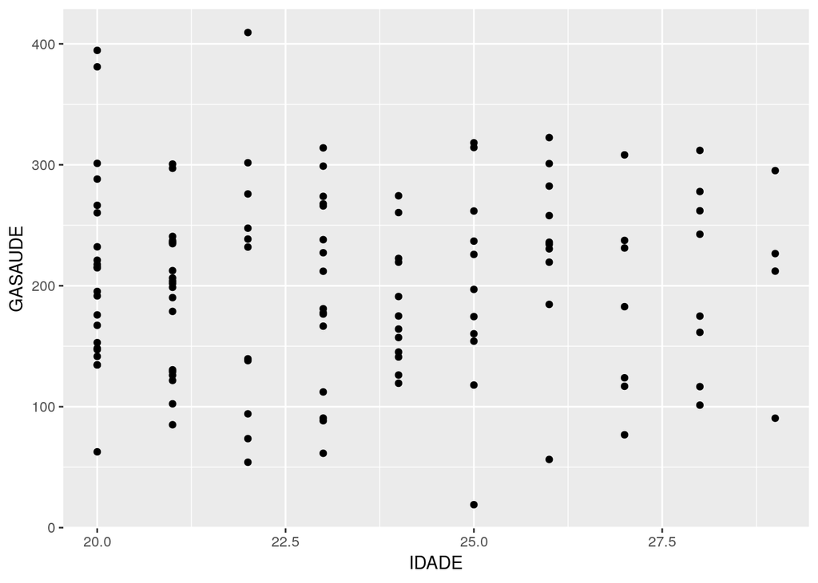

```r
# Exemplo de relacionamento entre variáveis: comportamento NÃO LINEAR
# Esse exemplo é idêntico ao da figura 2.2 e descrito acima, por isso, a relação linear entre Gasto com Saúde x Idade é FRACA. CONCLUSÃO: Não vale a pena verificar mais nenhum dado para relações lineares.
ggplot(data = dados, aes(x = IDADE, y = GASAUDE)) + geom_point()
```

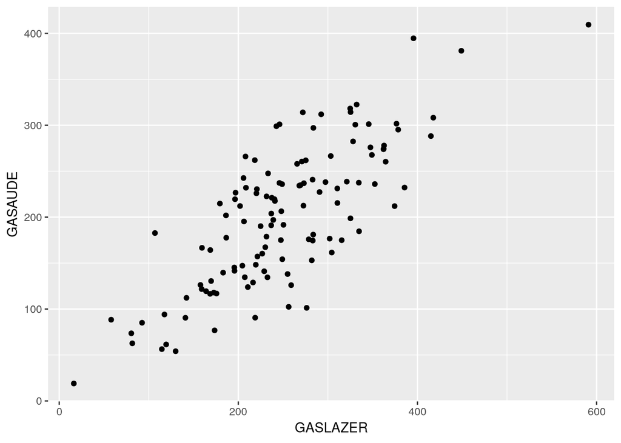

```r
# Exemplo de relacionamento entre variáveis: comportamento LINEAR (+)
# Nesta situação, se pegar um ponto em X (Gasto com Lazer), verifico que o aumento ou redução é acompanhado por Y (Gasto com Saúde). Daí a dependência e o relacionamento.
ggplot(data = dados, aes(x = GASLAZER, y = GASAUDE)) + geom_point()
```